# HSC Survey Results

# German Bank Survey # 1 Results from 04/08/2025

## Survey Details

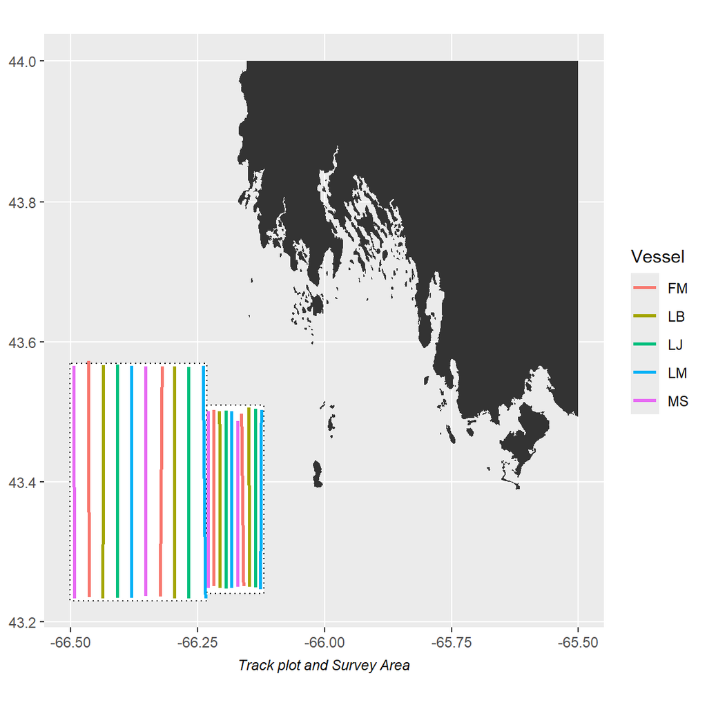

All vessels ran two transects in the German Bank box and two transect in the Seal Island Box.

There was a plankton tow and replicate conducted and CTD cast by Lady Melissa.

No tags were applied during this survey.

Samples were obtained for target strength estimation.

### Acoustic Equipment

Each vessel was equipped with a Simrad ES38-18/200-18C combi (2-in-1) transducer prior to the survey that contains a 38kHz split beam and 200 kHz single beam transducer. Data was logged to the computer hard-drive for post-processing. All participating boats were calibrated on 38kHz before the survey.

## Survey Results

### Main Results

The results are subject to change as DFO will re-evaluate data editing, area estimation and apply a target strength.

**Preliminary biomass prediction for German Bank using standardized parallel transects is 6,194mt. The preliminary biomass estimate for Seal Island is 1,160mt.**

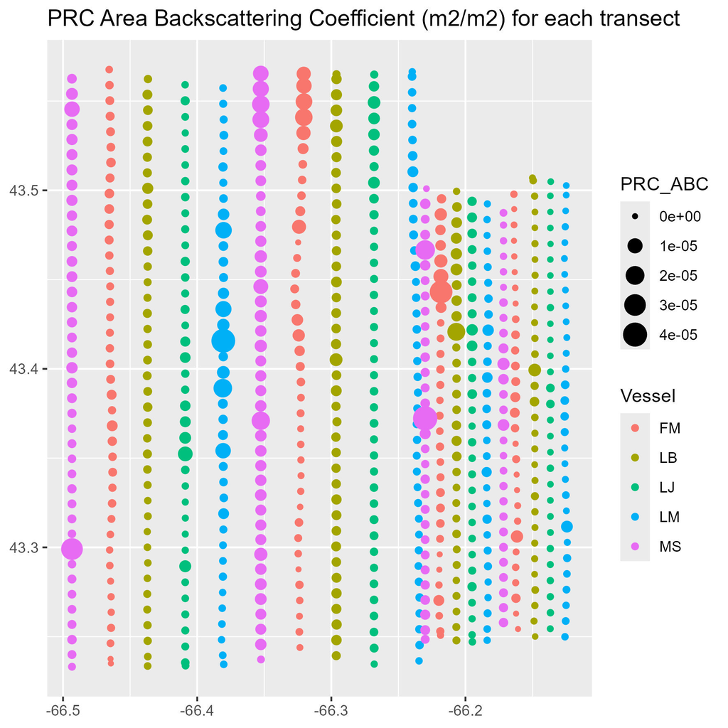

### Transect Details

Table 1: Transect Details

| Vessel | Transect # | Date/Time Start | Date/Time End | X | Y | Xend | Yend | Start Lat | Start Lon | End Lat | End Lon | Location | Distance (km) | Speed |
| --- | --- | --- | --- | --- | --- | --- | --- | --- | --- | --- | --- | --- | --- | --- |
| FM | T01 | 2025-08-04 21:49:10 | 2025-08-05 00:14:00 | -66.46546 | 43.57314 | -66.46434 | 43.23497 | NA | NA | NA | NA | GB | 38.93 | 8.71 |
| FM | T02 | 2025-08-05 00:48:14 | 2025-08-05 03:09:40 | -66.32401 | 43.23549 | -66.32059 | 43.56529 | NA | NA | NA | NA | GB | 37.74 | 8.64 |
| FM | T03 | 2025-08-05 03:42:14 | 2025-08-05 05:30:16 | -66.21922 | 43.50282 | -66.21859 | 43.25075 | NA | NA | NA | NA | GB | 29.18 | 8.75 |
| FM | T04 | 2025-08-05 05:52:31 | 2025-08-05 07:36:35 | -66.15983 | 43.25044 | -66.16389 | 43.49782 | NA | NA | NA | NA | GB | 28.39 | 8.84 |
| LB | T01 | 2025-08-04 20:32:49 | 2025-08-04 22:56:19 | -66.43692 | 43.56682 | -66.43694 | 43.23354 | NA | NA | NA | NA | GB | 38.14 | 8.61 |
| LB | T02 | 2025-08-04 23:36:19 | 2025-08-05 02:11:20 | -66.29646 | 43.23344 | -66.29618 | 43.56502 | NA | NA | NA | NA | GB | 37.97 | 7.94 |
| LB | T03 | 2025-08-05 02:46:16 | 2025-08-05 04:37:56 | -66.20721 | 43.50157 | -66.20674 | 43.24789 | NA | NA | NA | NA | GB | 29.12 | 8.45 |
| LB | T04 | 2025-08-05 04:58:59 | 2025-08-05 06:40:13 | -66.14796 | 43.24966 | -66.15005 | 43.50698 | NA | NA | NA | NA | GB | 29.22 | 9.35 |
| LJ | T01 | 2025-08-04 20:55:31 | 2025-08-04 23:20:35 | -66.40881 | 43.56805 | -66.40869 | 43.23375 | NA | NA | NA | NA | GB | 37.19 | 8.31 |
| LJ | T02 | 2025-08-04 23:56:24 | 2025-08-05 02:20:51 | -66.26774 | 43.23319 | -66.26803 | 43.56484 | NA | NA | NA | NA | GB | 36.90 | 8.27 |
| LJ | T03 | 2025-08-05 02:51:01 | 2025-08-05 04:40:56 | -66.19500 | 43.50262 | -66.19484 | 43.24709 | NA | NA | NA | NA | GB | 28.42 | 8.38 |
| LJ | T04 | 2025-08-05 05:00:19 | 2025-08-05 06:46:58 | -66.13695 | 43.24951 | -66.13642 | 43.50485 | NA | NA | NA | NA | GB | 28.43 | 8.64 |
| LM | T01 | 2025-08-04 20:56:45 | 2025-08-04 23:16:31 | -66.38047 | 43.56598 | -66.38023 | 43.23449 | NA | NA | NA | NA | GB | 37.59 | 8.71 |
| LM | T02 | 2025-08-04 23:51:18 | 2025-08-05 02:17:21 | -66.23492 | 43.23311 | -66.23967 | 43.56642 | NA | NA | NA | NA | GB | 37.68 | 8.36 |
| LM | T03 | 2025-08-05 02:43:35 | 2025-08-05 04:36:31 | -66.18357 | 43.50097 | -66.18383 | 43.24798 | NA | NA | NA | NA | GB | 28.68 | 8.23 |
| LM | T04 | 2025-08-05 04:54:12 | 2025-08-05 06:40:15 | -66.12652 | 43.24669 | -66.12484 | 43.50269 | NA | NA | NA | NA | GB | 28.99 | 8.85 |
| MS | T01 | 2025-08-04 20:38:38 | 2025-08-04 23:01:50 | -66.49420 | 43.56580 | -66.49334 | 43.23314 | NA | NA | NA | NA | GB | 39.26 | 8.88 |
| MS | T02 | 2025-08-04 23:41:16 | 2025-08-05 02:11:59 | -66.35234 | 43.23637 | -66.35258 | 43.56543 | NA | NA | NA | NA | GB | 39.10 | 8.40 |
| MS | T03 | 2025-08-05 02:52:56 | 2025-08-05 04:42:59 | -66.22904 | 43.50130 | -66.23002 | 43.24852 | NA | NA | NA | NA | GB | 29.66 | 8.73 |
| MS | T04 | 2025-08-05 05:04:55 | 2025-08-05 06:39:46 | -66.17154 | 43.25008 | -66.17167 | 43.48739 | NA | NA | NA | NA | GB | 27.70 | 9.46 |

### Survey Summary

Table 2: Acoustic Survey Results

| Vessel | Transect No. | Target Strength (db/kg) | Mean Sa (/m2) | Biomass Density (kg/m2) |
| --- | --- | --- | --- | --- |
| MS | T02 | -35.5 | -52.901 | 0.018 |
| LM | T01 | -35.5 | -54.289 | 0.013 |
| MS | T03 | -35.5 | -54.803 | 0.012 |
| MS | T01 | -35.5 | -55.463 | 0.010 |
| FM | T03 | -35.5 | -55.756 | 0.009 |
| FM | T02 | -35.5 | -56.156 | 0.009 |
| LB | T02 | -35.5 | -56.915 | 0.007 |
| LB | T03 | -35.5 | -57.472 | 0.006 |
| LJ | T02 | -35.5 | -59.211 | 0.004 |
| LJ | T01 | -35.5 | -59.376 | 0.004 |
| MS | T04 | -35.5 | -59.932 | 0.004 |
| LB | T01 | -35.5 | -60.170 | 0.003 |
| LJ | T03 | -35.5 | -60.681 | 0.003 |
| FM | T01 | -35.5 | -61.001 | 0.003 |
| LM | T02 | -35.5 | -61.207 | 0.003 |
| LM | T03 | -35.5 | -61.465 | 0.003 |
| FM | T04 | -35.5 | -62.559 | 0.002 |
| LB | T04 | -35.5 | -63.957 | 0.001 |
| LM | T04 | -35.5 | -64.185 | 0.001 |
| LJ | T04 | -35.5 | -68.417 | 0.001 |

Note:  
Transects are listed from greatest to least backscatter.

Table 3: Survey Summary Table

| Layer | Target Strength | Area (km2) | Mean Sa | Density (kg/m2) | Biomass (tons) | Percent Area | Percent Biomass | Standard Error (tons) | Standard Error (%) |
| --- | --- | --- | --- | --- | --- | --- | --- | --- | --- |
| German Bank | -35.5 | 826 | -56.7503 | 0.0075 | 6,193.766 | NA | NA | 1,345.73 | 21.73 |
| Seal Island | -35.5 | 274 | -59.2334 | 0.0042 | 1,159.863 | NA | NA | 326.41 | 28.14 |
| School Survey | NA | NA | NA | NA | NA | NA | NA | NA | NA |

### Greatest Biomass Densities

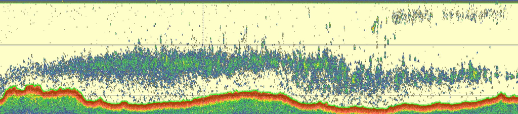

A snip from the transect with the greatest biomass density (kg/m2)

The single point with the largest biomass density (kg/m2) was recorded by **MS**, at the following location:

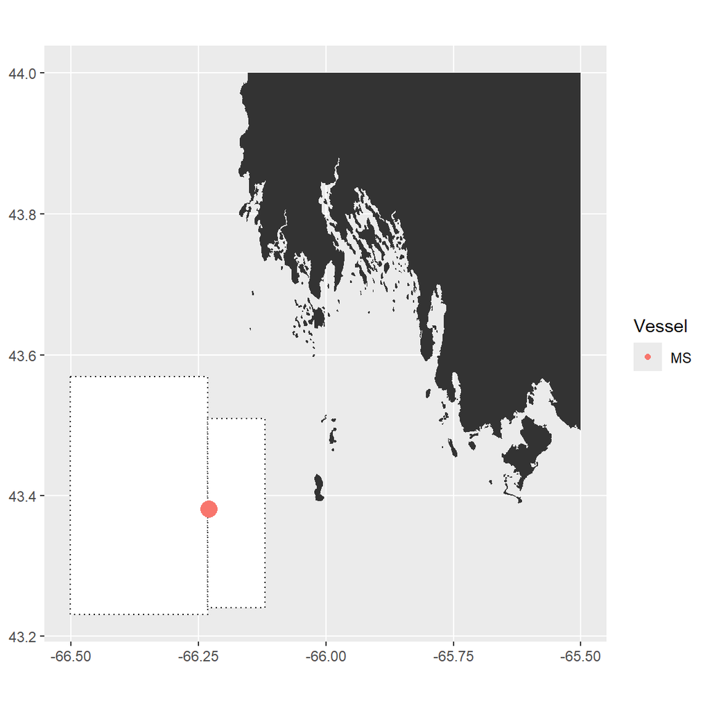

The transect with the greatest average biomass density (kg/m2) was recorded by **MS**, at the following location:

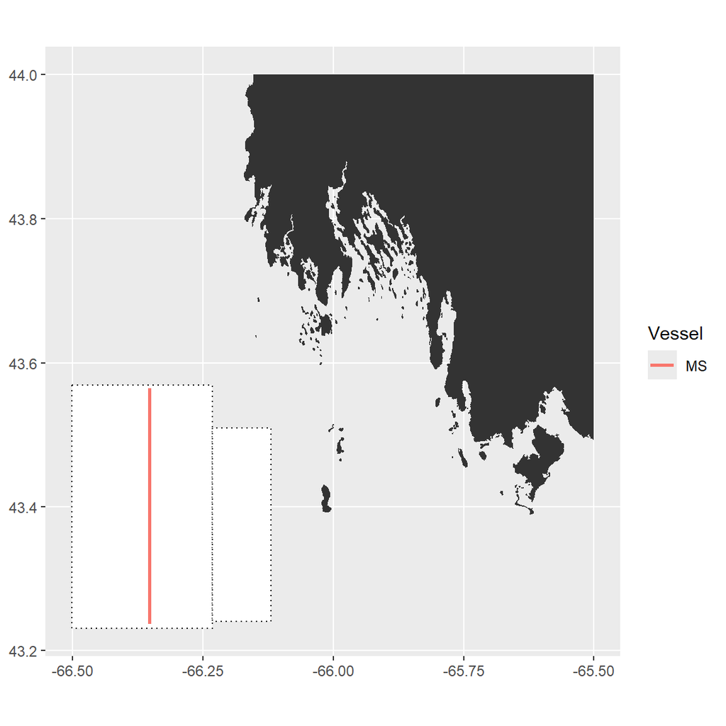

### Annual Summaries

This table does not include the biomass from adhoc surveys.

Table 4: Annual Comparison Table

| Ground | Survey Number | Current Year Survey Date | Current Year HSC Estimate | Current Year HSC Turnover Adjusted | Previous Year Survey Date | Previous Year HSC Estimate | Previous Year HSC Turnover Adjusted | Previous Year DFO Estimate | Previous Year DFO Turnover Adjusted |
| --- | --- | --- | --- | --- | --- | --- | --- | --- | --- |
| German Bank | 1 | 2025-08-04 | 6,193.766 | NA | 2024-08-04 | 12,233 | 12,233 | 5,026 | 5,026 |
| Seal Island | 1 | 2025-08-04 | 1,159.863 | NA | 2024-08-04 | 45,930 | 45,930 | 31,328 | 31,328 |
| German Bank | 2 | NA | NA | NA | 2024-08-18 | 14,054 | 11,668 | 11,333 | 10,353 |
| Seal Island | 2 | NA | NA | NA | 2024-08-18 | 6,285 | 6,285 | 5,241 | 5,241 |
| German Bank | 3 | NA | NA | NA | 2024-09-02 | 15,499 | 12,639 | 11,070 | 8,899 |
| Seal Island | 3 | NA | NA | NA | 2024-09-02 | 3,770 | 3,770 | 2,914 | 2,914 |
| German Bank | 4 | NA | NA | NA | 2024-09-15 | 24,824 | 21,033 | 21,117 | 18,363 |
| Seal Island | 4 | NA | NA | NA | 2024-09-15 | 1,369 | 1,369 | 1,538 | 1,538 |
| German Bank | 5 | NA | NA | NA | 2024-09-29 | 10,595 | 5,068 | 11,196 | 6,588 |
| Seal Island | 5 | NA | NA | NA | 2024-09-29 | 3,134 | 3,134 | 5,125 | 5,125 |
| German Bank | 6 | NA | NA | NA | 2024-10-20 | 5,151 | 4,071 | 18,989 | 17,847 |
| Seal Island | 6 | NA | NA | NA | 2024-10-20 | 2,927 | 2,927 | 3,543 | 3,543 |
| German Bank | 7 | NA | NA | NA | 2024-11-03 | 3,004 | 1,999 | 2,989 | 0 |
| Seal Island | 7 | NA | NA | NA | 2024-11-03 | 1,089 | 1,089 | 324 | 324 |

Table 5: Annual Summary Table

| Year | Ground | Survey_Number | Survey_Date | HSC_Estimate | HSC_Turnover_Adjusted |
| --- | --- | --- | --- | --- | --- |
| 2025 | German Bank | 1 | 2025-08-04 | 6,193.766 | NA |
| 2025 | Seal Island | 1 | 2025-08-04 | 1,159.863 | NA |

## Vessel Performance

### Speed

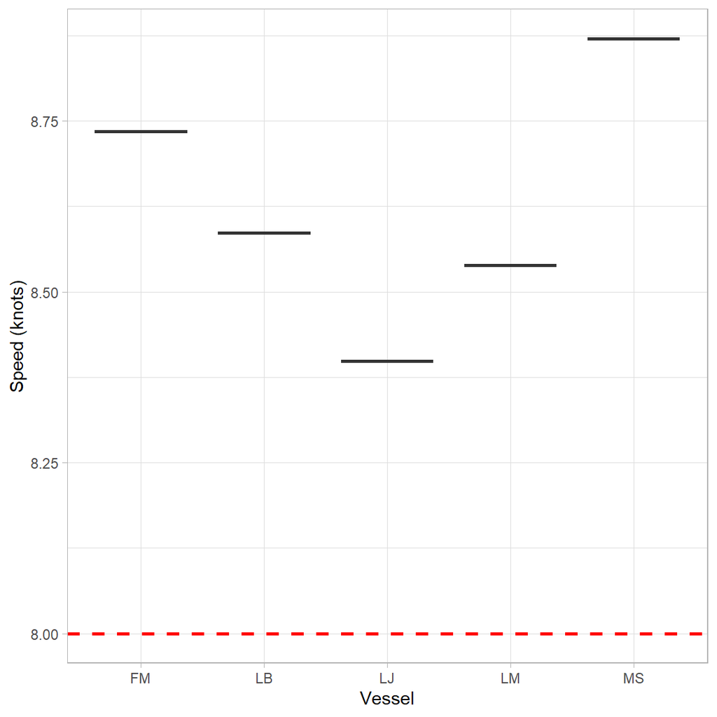

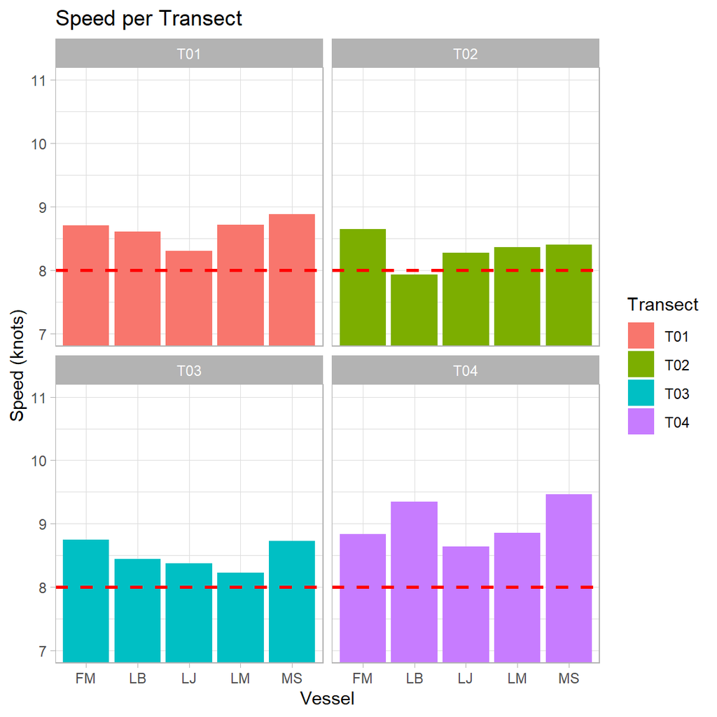

Average vessel speed was 8.63. This is above the 8 knot requirement; vessels are urged to slow down to prevent backscatter noise from interfering with the acoustic data.

The speed for each transect are rudimentary and are calculated based on distance. If a significant amount of distance is cut, the speed will appear slower.